# Rによる因果媒介分析1 Baron-Kenny法

2021-01-19

## はじめに

Rによる因果媒介分析のまとめ。今回は媒介変数・アウトカムが連続変数の場合のパラメトリックな手法を扱う。比較的お手軽にできる解析手法だが、同時に厳しい仮定を必要とする手法でもある。なので実際の解析から感度分析による結果の解釈までまとめてみたい。

## Baron-Kenny法

Baron-Kenny法は線形モデルによって媒介効果を推定する手法。アウトカムと媒介変数を応答変数とした2回の回帰分析を行い、媒介効果を推定。 使用するのはRのjobsデータ（JOBS2 field experetiment）。

```r
library(mediation)
data("jobs")
```

### ステップ1：媒介変数に対する回帰分析

まず媒介変数を応答変数、曝露変数と交絡因子を説明変数とした回帰分析を行う。

```r
model.m <- lm(job_seek~treat+depress1+econ_hard+sex+age+occp+marital+nonwhite+educ+income, data=jobs)
```

### ステップ2：アウトカムに対する回帰分析

次にアウトカムを応答変数、曝露変数、媒介変数、交絡因子を説明変数として回帰分析を実施。

```r
model.y <- lm(depress2~treat+job_seek+depress1+econ_hard+sex+age+occp+marital+nonwhite+educ+income, data=jobs)
```

### ステップ3：媒介効果の点推定値・95%信頼区間の推定

上記で行った回帰分析の結果をもとに媒介効果を推定するため、mediate関数を使う。ここでは媒介効果の点推定値と95%信頼区間の推定方法について設定することができる。mediate関数でboot=TRUEとすることでノンパラメトリックブートストラップ法による信頼区間が推定可能（分布を仮定しないが膨大な計算が必要）。

| mediate関数 | 内容 |
| --- | --- |
| boot=TRUE | ノンパラメトリックブートストラップ法による信頼区間 |
|  | (デフォルト、boot=FALSE)準ベイズモンテカルロ法 |
| sims=試行回数 | シミュレーション回数 |
| treat=“変数” | 治療・曝露に該当する変数の指定 |
| mediator=“変数” | 媒介変数に該当する変数の指定 |

```r
m.out <- mediate(model.m, model.y, boot=TRUE, sims=1000, treat="treat", mediator="job_seek")
summary(m.out)
```

```
##
## Causal Mediation Analysis
##
## Nonparametric Bootstrap Confidence Intervals with the Percentile Method
##
##                Estimate 95% CI Lower 95% CI Upper p-value
## ACME            -0.0137      -0.0342         0.00    0.12
## ADE             -0.0368      -0.1150         0.05    0.38
## Total Effect    -0.0505      -0.1334         0.03    0.24
## Prop. Mediated   0.2718      -1.3469         2.84    0.29
##
## Sample Size Used: 899
##
##
## Simulations: 1000
```

### ステップ4：感度分析

媒介分析では、曝露ーアウトカム間と媒介変数ーアウトカム間の未測定交絡が無いことが仮定される（Imaiらは“Sequential Ignorability”と定義）。しかしこの仮定は非常に厳しいもので、**現実には満たされることはないと考えるべき**。したがって感度分析によって、どの程度仮定が満たされていないかを定量化する必要がある。ImaiらはBaron-Kenny法・SEMによる媒介分析に対する感度分析を提案している（Imai, K. Statistical Science. 2010; Imai, K. Phycological Science. 2010）。  
感度分析はステップ1回帰分析の残差とステップ2回帰分析の残差の間の相関係数で評価を行う。残差に相関があれば、潜在的な未測定交絡がある可能性があり、推定が妥当でないことが示唆される。また残差の相関係数は解釈が難しいという問題があり、Imaiらは代わりに決定係数による感度分析を提案している（Imai, K. Statistical Science. 2010;）。決定係数により、未測定交絡によってACMEがどの程度影響を受けるかを定量化する。以下では両方の感度分析を行う。  
感度分析は以下のコードで実行できる。sens.par=“R2”で決定係数、指定しなければ相関係数による感度分析の結果がプロットされる。

| plot関数 | 内容 |
| --- | --- |
| sens.par=“R2” | 決定係数による感度分析（デフォルトは相関係数） |
| r.type=1 | 未測定交絡によって説明される原因不明の分散比率での感度分析 |
| =2 | 未測定交絡によって説明される元の分散比率での感度分析 |
| sign.prod=1 | 未測定交絡の係数符号が媒介変数・アウトカムで同じ場合 |
| =-1 | 係数の符号が異なるもとでの感度分析 |

```r
s.out <- medsens(m.out)
summary(s.out)
```

```
##
## Mediation Sensitivity Analysis for Average Causal Mediation Effect
##
## Sensitivity Region
##
##        Rho    ACME 95% CI Lower 95% CI Upper R^2_M*R^2_Y* R^2_M~R^2_Y~
##  [1,] -0.9  0.1183      -0.0274       0.2640         0.81       0.5293
##  [2,] -0.8  0.0715      -0.0166       0.1597         0.64       0.4182
##  [3,] -0.7  0.0489      -0.0115       0.1093         0.49       0.3202
##  [4,] -0.6  0.0342      -0.0081       0.0766         0.36       0.2353
##  [5,] -0.5  0.0232      -0.0057       0.0520         0.25       0.1634
##  [6,] -0.4  0.0142      -0.0038       0.0321         0.16       0.1046
##  [7,] -0.3  0.0064      -0.0025       0.0153         0.09       0.0588
##  [8,] -0.2 -0.0007      -0.0049       0.0036         0.04       0.0261
##  [9,] -0.1 -0.0073      -0.0172       0.0026         0.01       0.0065
## [10,]  0.0 -0.0137      -0.0312       0.0037         0.00       0.0000
## [11,]  0.1 -0.0202      -0.0453       0.0050         0.01       0.0065
## [12,]  0.2 -0.0268      -0.0600       0.0065         0.04       0.0261
## [13,]  0.3 -0.0338      -0.0757       0.0080         0.09       0.0588
## [14,]  0.4 -0.0416      -0.0931       0.0098         0.16       0.1046
## [15,]  0.5 -0.0507      -0.1132       0.0118         0.25       0.1634
## [16,]  0.6 -0.0617      -0.1378       0.0144         0.36       0.2353
## [17,]  0.7 -0.0764      -0.1706       0.0177         0.49       0.3202
## [18,]  0.8 -0.0990      -0.2209       0.0229         0.64       0.4182
## [19,]  0.9 -0.1458      -0.3252       0.0337         0.81       0.5293
##
## Rho at which ACME = 0: -0.2
## R^2_M*R^2_Y* at which ACME = 0: 0.04
## R^2_M~R^2_Y~ at which ACME = 0: 0.0261
```

まずsummary()で表示されたテーブルについて。左から順に、残差の相関係数、ACMEの点推定値、ACMEの95%信頼区間下限と上限、未測定交絡によって説明される原因不明の分散比率、未測定交絡によって説明される元の分散比率、を示している。またテーブルの下部では、ACME=0での相関係数、決定係数による指標の値がわかる。これらの詳細な定義式はImaiらの原著論文を参考に。

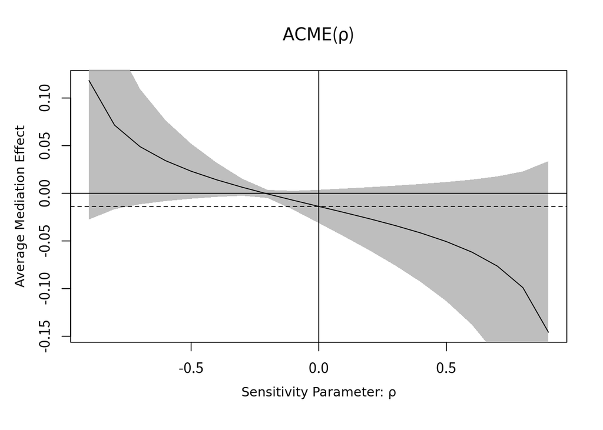

```r
plot(s.out)
```

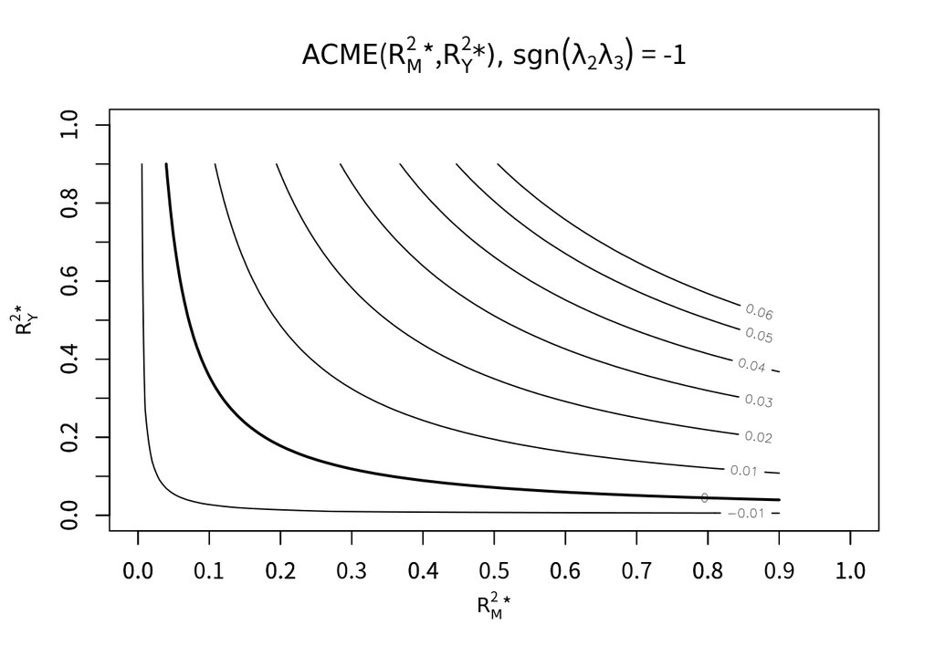

```r
plot(s.out, sens.par="R2", r.type=1, sign.prod=-1)
```

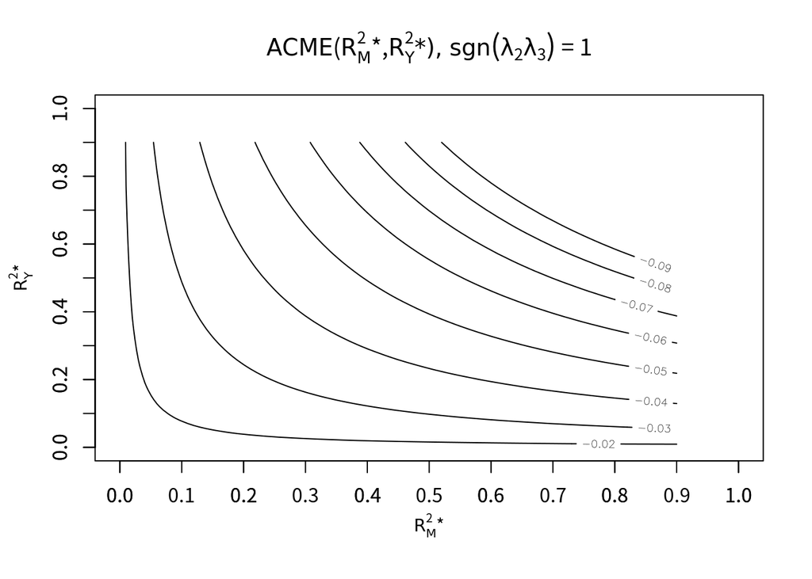

```r
plot(s.out, sens.par="R2", r.type=1, sign.prod=1)
```

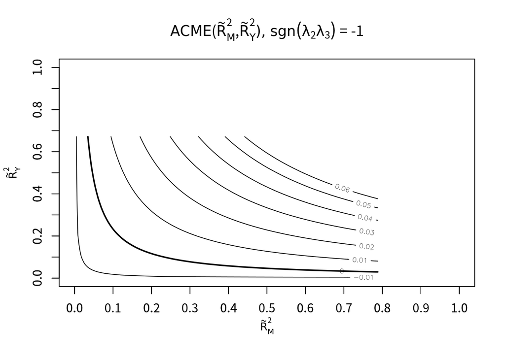

```r
plot(s.out, sens.par="R2", r.type=2, sign.prod=-1)
```

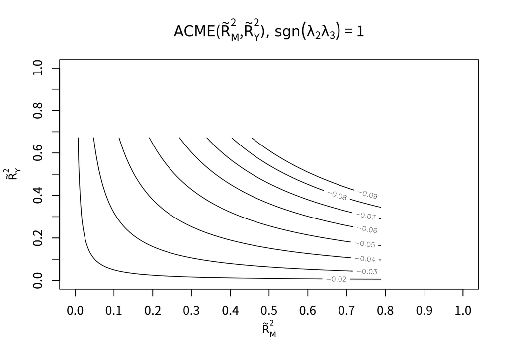

```r
plot(s.out, sens.par="R2", r.type=2, sign.prod=1)
```

## 終わりに

以上Baron-Kenny法による因果媒介分析を扱い、実際のデータをもとにRコードで解析してみた。今回は媒介変数とアウトカムが連続変数の場合を扱った。この手法は厳しい仮定を置いてしまうものの、感度分析を行うことで解析結果が妥当であるか検討することができる。

## 参考文献

[1. Advances in social science Research using R（第8章 Causal Mediation Analysis Using R）](https://www.springer.com/gp/book/9781441917638)  
2. Imai, K. et al. Identification, Inference and Sensitivity Aanalysis for Causal Mediation Effects. Statistical Science. 2010; 25(1):51-71.  
3. Imai, K. et al. A General Approach to Causal Mediation Analysis. Phycological Methods. 2010;15(4):309-334.